# Growth Rate of Male and Female Black Bears

Tori Chevalier

21 May, 2020

# Packages and Data

```r
setwd("C:/Users/cantb/OneDrive - Northland College - WI/Graphs")
library(tidyverse)
library(patchwork)
```

```r
bb <- read.csv("BlackBear.csv") %>%
  rename(Age="Age..yr.",
         Length="Body.length..cm.",
         Chest="Chest.girth..cm.",
         Weight="Body.weight..kg.") %>%
  mutate(Sex=plyr::mapvalues(Sex,from=c("FEMALE","MALE"),
                             to=c("Female","Male")),
         Date=as.Date(Date,format="%m/%d/%Y"),
         Year=lubridate::year(Date),
         Mon=lubridate::month(Date,label=TRUE))
head(bb)
```

[output not shown]

```r
bl <- ggplot(data=bb, mapping=aes(x=Age,y=Length,fill=Sex)) +
geom_point(pch=21,alpha=0.75,size=3) +
  geom_smooth(se=FALSE,color="black") +
scale_x_continuous(name="Age",breaks=seq(0,20,1)) +
scale_y_continuous(name="Body Length (cm)",breaks=seq(0,250,25),expand=expansion(mult=c(0,0.1))) +
  scale_fill_manual(values = c("red","blue")) +
  theme_bw() +
  theme(legend.justification=c(0.98,0.01),legend.position=c(0.99,0.1),legend.text=element_text(size=8),legend.title=element_text(size=10),legend.key.size=unit(4,"mm"),panel.grid.minor=element_blank(),axis.title.x=element_blank())

cg <- ggplot(data=bb, mapping=aes(x=Age,y=Chest,fill=Sex)) +
geom_point(pch=21,alpha=0.75,size=3) +
  geom_smooth(se=FALSE,color="black") +
scale_x_continuous(name="Age",breaks=seq(0,20,1)) +
scale_y_continuous(name="Chest Girth (cm)",breaks=seq(0,200,25),expand=expansion(mult=c(0,0.15))) +
  scale_fill_manual(values = c("red","blue")) +
  theme_bw() +
  theme(legend.position = "none",panel.grid.minor=element_blank(),axis.title.x=element_blank())

bw <- ggplot(data=bb, mapping=aes(x=Age,y=Weight,fill=Sex)) +
geom_point(pch=21,alpha=0.75,size=3) +
  geom_smooth(se=FALSE,color="black") +
scale_x_continuous(name="Age",breaks=seq(0,20,1)) +
scale_y_continuous(name="Body Weight (kg)",breaks=seq(0,250,25),expand=expansion(mult=c(0,0.1))) +
  scale_fill_manual(values = c("red","blue")) +
  theme_bw() +
  theme(legend.position = "none",panel.grid.minor=element_blank())
```

# Growth Rate of Male and Female Black Bears

The data for this graph was sourced from a study in which measurements of Black bears (Ursus americanus) were taken from 2000 to 2012. Bears were measured throughout Florida, on both public and private land, to show the best representation of the black bear population. Three measurements were taken of each bear: body weight, chest girth, and body length. Bears from age 0 to twenty years old were measured. 203 females and 304 males were measured. Food source varied among bears, between what was considered a natural diet, to what was considered a diet consisting mainly of human food.

The question this graph is exploring is how growth rate, and general size differs between male and female black bears. The graph includes all measurements taken from the study (body length, chest girth, and body weight).

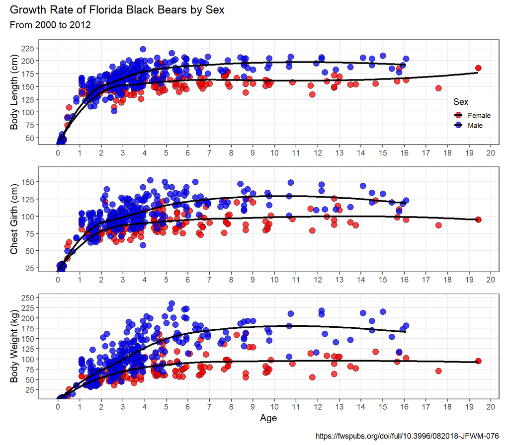

```r
fg <- bl / cg / bw

fg + plot_annotation(title="Growth Rate of Florida Black Bears by Sex",subtitle="From 2000 to 2012", caption="https://fwspubs.org/doi/full/10.3996/082018-JFWM-076")
```

I chose to do a composite of three graphs because there so no other feasible way to show all three measurements without the graph looking incredibly messy and confusing. I chose to do a point graph, as it best shows how the measurements are distributed by age. To best show the data I widened the graph to make it more clear how it was distributed by age group. I made the male black bear points be blue and female points be red; the colors are intuitive. A loess regression line was added, to aid the reader in seeing how each sex changed over time. I chose a loess versus a linear regression line, as a linear regression line shows the closest fit for all the data, while a loess line curves with the data, and shows the best fit for smaller sets of the data. The x axis breaks were changed to every year, versus the automatic five years, so the reader could more clearly tell which age the dots fell into. The x axis title was removed from all but the bottom graph, as it was redundant. Only one legend was used and placed in the top graph, as that is what the reader would first look at.